# Lecture 11. Data Visualization

Zechariah Meunier

2025-05-07

## Data Tables

### Purpose

Data tables show specific values of qualitative and quantitative data and can be used in many situations:

- You want readers to look up exact values (e.g., measurements, statistics, coefficients).
- The data are not easily visualized (e.g., model parameters, categorical comparisons with many groups).
- You need to report summary statistics (e.g., means, standard errors, p-values) that support a result described in the text.
- The goal is to compare exact numbers across rows or columns (e.g., species counts).

### Design Principles

The caption goes above the data table and the word “table” is never abbreviated. I prefer having the table title bold and separated from the rest of the caption with a period.

The header row is often separated from the caption and other rows with horizontal lines. Occasionally, the header row is in boldface font.

If a column contains qualitative data, it is left-aligned. If it contains quantitative data, it is center-aligned. The units of the quantitative data are given in parentheses after the variable name.

**Table 1**. Example table showing appropriate formatting.

| Country | Population size (millions) | Official language |
| --- | --- | --- |
| United States of America | 340.1 | English* |
| Mexico | 129.7 | None |
| Canada | 40.1 | English, French |

*Designated in EO 14224 on March 1, 2025

## Figures

### Purpose

Figures show representations of qualitative and quantitative data and can be used in many situations:

- The main goal is to reveal patterns, trends, or relationships in the data.
- You’re comparing distributions, time series, spatial patterns, or model fits.
- Visual presentation makes the results more intuitive or immediately interpretable.
- You want to highlight differences, correlations, or interactions.
- The audience benefits from a visual summary over raw numbers.

### Design Principles

The caption goes below the figure and the word “figure(s)” is abbreviated “Fig(s).” for in-text citations. As before, I prefer having the figure title bold and separated from the rest of the caption with a period.

For two-dimensional figures, there are five primary elements with which to display data:

- x-axis: usually reserved for the explanatory variable or time
- y-axis: usually reserved for the response variable
- color/shape/line scheme: denoting levels of a factor
  - strive for no more than 4 line types, 6 shapes, or 10 colors
- rows: denoting levels of a factor, where top-bottom order may be meaningful
- columns: denoting levels of a factor, where left-right order may be meaningful

**Note on color schemes:** Colors should be logical, meaningful, and distinct for people with all vision abilities (i.e., use colorblind-friendly palettes whenever possible).

## Palmer Antarctica LTER Example

This week, we will be working with several data sets from three Long Term Ecological Research (LTER) sites. The first is in Antarctica and includes data on charismatic penguins.

Consider some factors that might influence penguin size. For example, imagine I’m interested in assessing how penguin body mass changes by species, year, and island. I have four variables of interest:

- body mass (quantitative response)
- year (ordinal explanatory)
- island (nominal explanatory)
- species (nominal explanatory)

Which variables should be displayed on which elements?

```r
head(penguins)
```

```
##   species    island bill_len bill_dep flipper_len body_mass    sex year
## 1  Adelie Torgersen     39.1     18.7         181      3750   male 2007
## 2  Adelie Torgersen     39.5     17.4         186      3800 female 2007
## 3  Adelie Torgersen     40.3     18.0         195      3250 female 2007
## 4  Adelie Torgersen       NA       NA          NA        NA   <NA> 2007
## 5  Adelie Torgersen     36.7     19.3         193      3450 female 2007
## 6  Adelie Torgersen     39.3     20.6         190      3650   male 2007
```

Let’s make a quick plot showing these four variables.

```r
library(tidyverse)
```

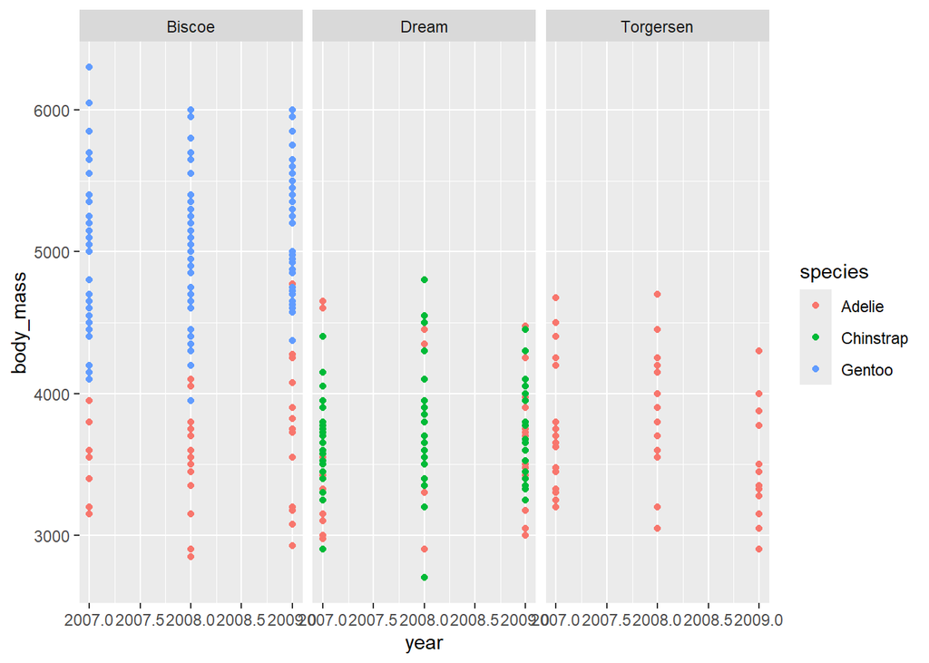

```r
ggplot(data = penguins,
       aes(x = year, y = body_mass, color = species)) +
  geom_point() +
  facet_wrap(~island)
```

The default ggplot settings aren’t great, so we will adjust some of the design elements. First, we’ll convert the `year` variable to a factor and adjust the title. We’ll also improve the titles for the y-axis and legend, and change the color scheme to a colorblind-friendly palette.

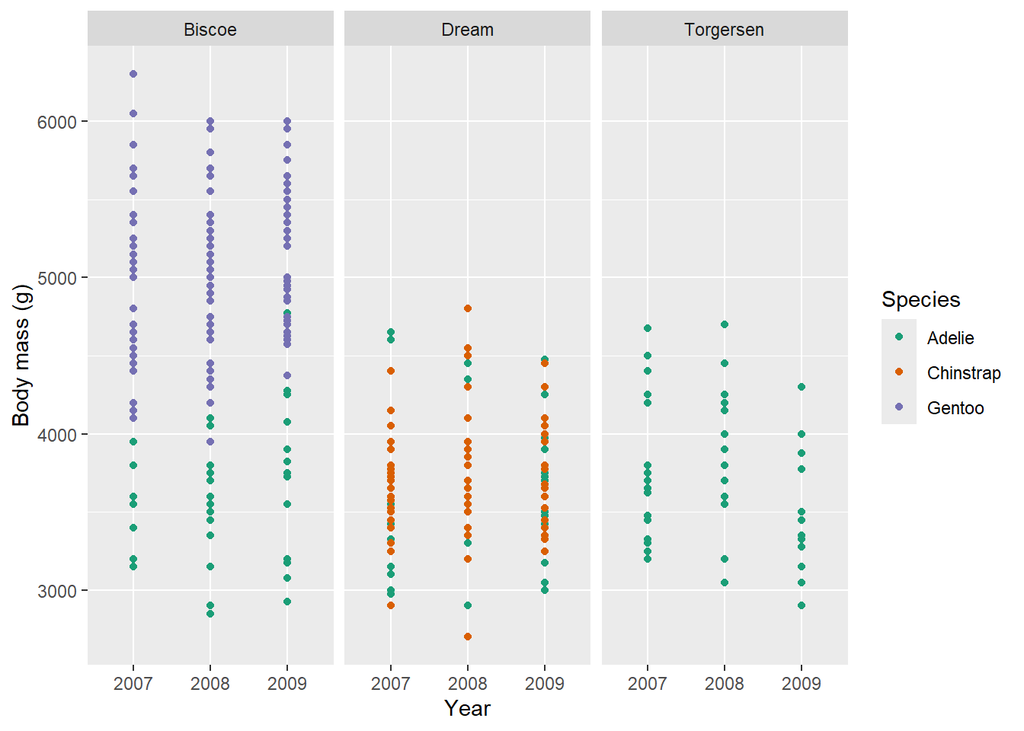

```r
ggplot(data = penguins,
       aes(x = factor(year), y = body_mass, color = species)) +
  geom_point() +
  facet_wrap(~island) +
  scale_x_discrete(name = "Year") +
  scale_y_continuous(name = "Body mass (g)") +
  scale_color_brewer(name = "Species", palette = "Dark2")
```

Now we want to improve the theme with a mix of pre-built and custom settings.

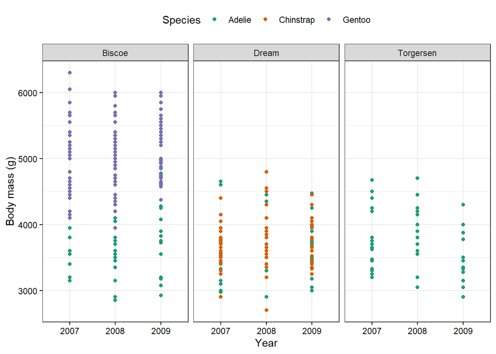

```r
ggplot(data = penguins,
       aes(x = factor(year), y = body_mass, color = species)) +
  geom_point() +
  scale_x_discrete(name = "Year") +
  scale_y_continuous(name = "Body mass (g)") +
  scale_color_brewer(name = "Species", palette = "Dark2") +
  facet_wrap(~island) +
  theme_bw() +
  theme(legend.position = "top",
        axis.text = element_text(color = "black"),
        axis.ticks = element_line(color = "black"))
```

Next we want to jitter the points and make them partially transparent so that we can see more details.

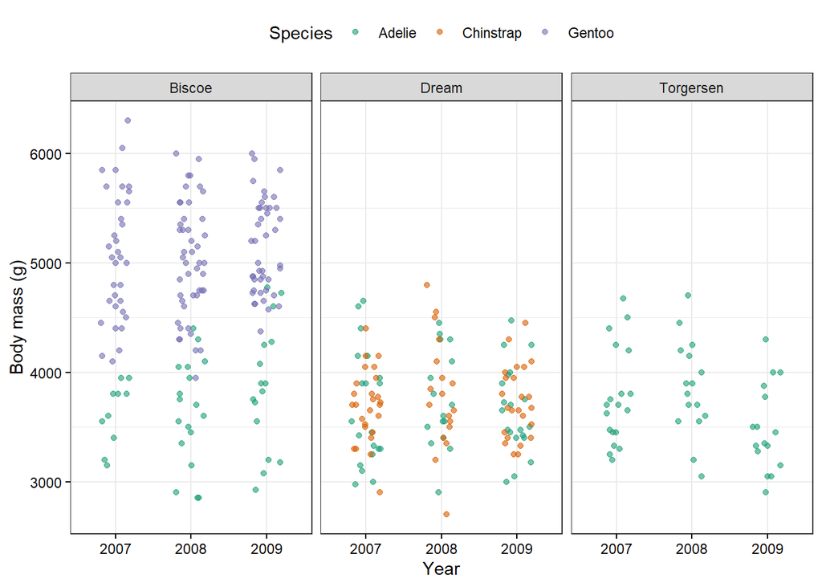

```r
ggplot(data = penguins,
       aes(x = factor(year), y = body_mass, color = species)) +
  geom_jitter(width = 0.2, height = 0, size = 1.5, alpha = 0.6) +
  scale_x_discrete(name = "Year") +
  scale_y_continuous(name = "Body mass (g)") +
  scale_color_brewer(name = "Species", palette = "Dark2") +
  facet_wrap(~island) +
  theme_bw() +
  theme(legend.position = "top",
        axis.text = element_text(color = "black"),
        axis.ticks = element_line(color = "black"))
```

Finally, we want to add mean body mass in addition to the raw data using the `stat_summary` function.

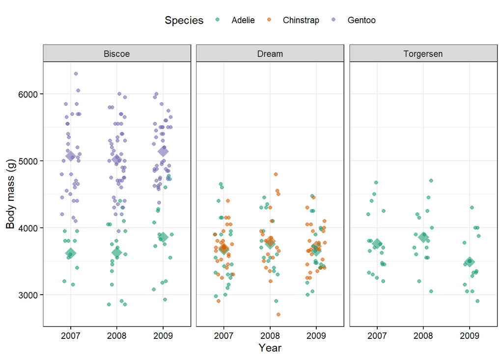

```r
ggplot(data = penguins,
       aes(x = factor(year), y = body_mass, color = species)) +
  stat_summary(fun = "mean", geom = "point", show.legend = FALSE,
               size = 5, shape = 18, alpha = 0.6) +
  geom_jitter(width = 0.2, height = 0, size = 1.5, alpha = 0.6) +
  scale_x_discrete(name = "Year") +
  scale_y_continuous(name = "Body mass (g)") +
  scale_color_brewer(name = "Species", palette = "Dark2") +
  facet_wrap(~island) +
  theme_bw() +
  theme(legend.position = "top",
        axis.text = element_text(color = "black"),
        axis.ticks = element_line(color = "black"))
```

## North Temperate Lakes LTER Example

Load dataset

```r
biomass <- read.csv("Madison Lakes Area Macrophyte Biomass.csv")
```

Store lake as a factor, add labels for lake and depth

```r
biomass$lakeid <- factor(biomass$lakeid,
                         levels = c("FI","ME","MO","WI"))

lakelabels <- c("FI" = "Fish Lake",
                "ME" = "Lake Mendota",
                "MO" = "Lake Monona",
                "WI" = "Lake Wingra")

depthlabels <- c("1" = "1 m", "1.5" = "1.5 m",
                 "2" = "2 m", "2.5" = "2.5 m",
                 "3" = "3 m", "3.5" = "3.5 m")
```

Check to see how well-represented each depth is in each lake

```r
table(biomass$depth, biomass$lakeid)
```

```
##
##         FI   ME   MO   WI
##   1    640 1732  648  620
##   1.5  647 1754  648  620
##   2    652 1748  644  604
##   2.5  648 1720  644  584
##   3    636 1699  624  466
##   3.3    0    0    0    4
##   3.5  574 1615  580  204
##   4    518 1394  503   36
##   4.5   48   48   16    0
```

Create theme and color scheme

```r
plantcolors <- c("darkolivegreen3","darkgreen")

plottheme <- theme(axis.title = element_text(size = 10, color = "black"),
                   axis.text = element_text(size = 8, color ="black"),
                   axis.ticks = element_line(color = "black"),
                   panel.background = element_blank(),
                   panel.border = element_rect(fill = NA, color = "black"),
                   legend.key = element_blank(),
                   legend.position = "top",
                   legend.box.spacing = unit(0.1,"cm"),
                   legend.title = element_text(size = 10, color = "black"),
                   legend.text = element_text(size = 9, color = "black"))
```

Create a time series of biomass:

- x-axis: time
- y-axis: biomass
- colors: macrophyte group
- rows: depth
- columns: lakes

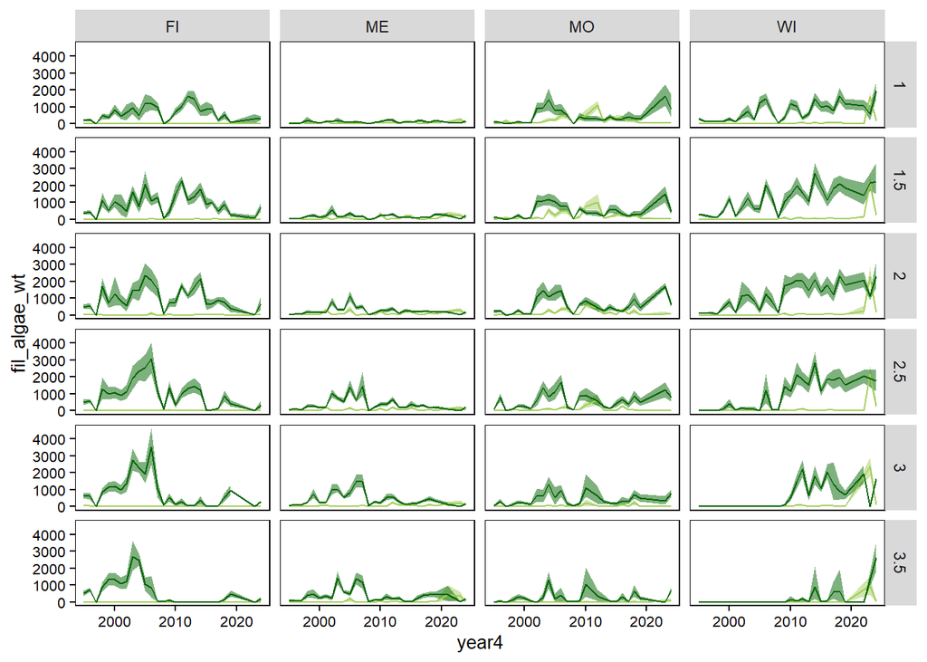

```r
ggplot(data = filter(biomass, !depth %in% c(3.3, 4, 4.5))) +
  #95% confidence intervals
  stat_summary(aes(x = year4, y = fil_algae_wt), fill = plantcolors[1],
               fun.data = "mean_cl_boot", geom = "ribbon", alpha = 0.5) +
  stat_summary(aes(x = year4, y = plant_wt_hand), fill = plantcolors[2],
               fun.data = "mean_cl_boot", geom = "ribbon", alpha = 0.5) +
  #means
  stat_summary(aes(x = year4, y = fil_algae_wt), color = plantcolors[1],
               fun = "mean", geom = "line") +
  stat_summary(aes(x = year4, y = plant_wt_hand), color = plantcolors[2],
               fun = "mean", geom = "line") +
  #design elements
  facet_grid(rows = vars(depth), cols = vars(lakeid)) +
  plottheme
```

Refine the plot by improving the labels, axis breaks, and adding a legend

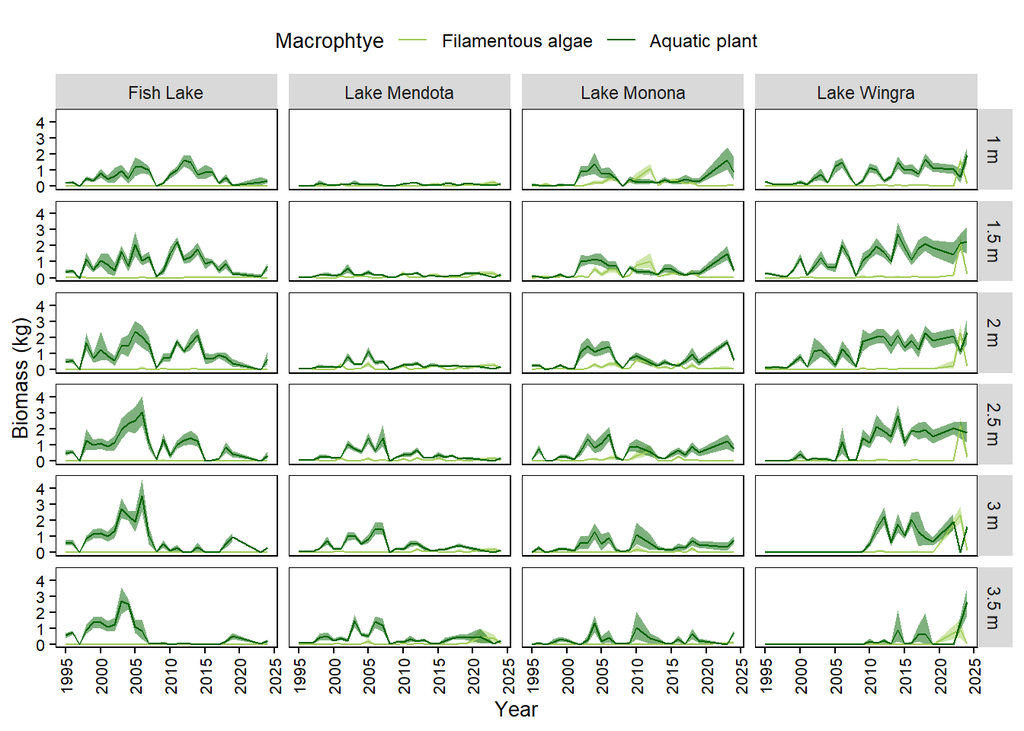

```r
ggplot(data = filter(biomass, !depth %in% c(3.3, 4, 4.5))) +
  #95% confidence intervals
  stat_summary(aes(x = year4, y = fil_algae_wt/1000), fill = plantcolors[1],
               fun.data = "mean_cl_boot", geom = "ribbon", alpha = 0.5) +
  stat_summary(aes(x = year4, y = plant_wt_hand/1000), fill = plantcolors[2],
               fun.data = "mean_cl_boot", geom = "ribbon", alpha = 0.5) +
  #means
  stat_summary(aes(x = year4, y = fil_algae_wt/1000, color = "1"),
               fun = "mean", geom = "line") +
  stat_summary(aes(x = year4, y = plant_wt_hand/1000, color = "2"),
               fun = "mean", geom = "line") +
  #design elements
  facet_grid(rows = vars(depth), cols = vars(lakeid),
             labeller = labeller(lakeid = lakelabels, depth = depthlabels)) +
  plottheme +
  scale_x_continuous(name = "Year", breaks = seq(1995,2025,5)) +
  scale_y_continuous(name = "Biomass (kg)") +
  scale_color_manual(name = "Macrophtye", values = plantcolors,
                     labels = c("Filamentous algae","Aquatic plant")) +
  theme(axis.text.x = element_text(color ="black", angle = 90, vjust = 0.5))
```

```r
ggsave("Figures/Biomass Time Series.png", dpi = 1200,
       width = 8, height = 6, units = "in")
```